# checkpoint2

Para o checkpoint 2 do problema 3, utilizaremos os dados sobre verbas alocadas por deputados para municípios, estados e fundações através de emendas parlamentares.

```r
detalhes_emendas <- read.csv("emendas_detalhes_parlamentar.csv")
```

# PCA

Para uma melhor sumarizaçao dos dados, iremos agrupar as emendas por mes e ano, e utilizaremos a coluna ‘VALOR_REPASSE_EMENDA’ para sumarizar o total repassado do governo federal para a emenda proposta que foi aprovada.

```r
detalhes_emendas <- detalhes_emendas %>%
  filter(!is.na(NOME_PARLAMENTAR), !is.na(DESC_ORGAO_SUP), !is.na(funcao.imputada)) %>%
  arrange(-ANO_PROP, -MES_PROP, DIA_PROP)

#agrupando por mes, ano e funçao imputada
  emendas_ano <- detalhes_emendas %>%
    group_by(funcao.imputada,ANO_PROP, MES_PROP) %>%
    summarise(total.valor.repasse.emenda = sum(VALOR_REPASSE_EMENDA))

# transformando funçoes imputadas em colunas
#assim ao final teremos por ano em cada mês os gastos de cada uma das funções imputadas
  emendas_ano_cast <- emendas_ano %>%
    cast(ANO_PROP+MES_PROP~funcao.imputada) %>%
    arrange(ANO_PROP,MES_PROP)

# trocando valores NA por 0
emendas_ano_cast <- do.call(data.frame,lapply(emendas_ano_cast, function(x) replace(x, is.na(x),0)))

#summary(emendas_ano_cast)
```

As variáveis são bastante assimétricas, iremos transformar para log para ajudar na visualizaçao.

```r
# Escala de log
emendas_ano_log <- log(emendas_ano_cast[,3:18])

#Transformando os valores de 'mês' em factor
emendas_ano_log$MES_PROP <- as.factor(emendas_ano_cast$MES_PROP)
emendas_ano_log$ANO_PROP <- as.factor(emendas_ano_cast$ANO_PROP)

#trocando os valores de -infinito por 0
emendas_ano_log <- do.call(data.frame,lapply(emendas_ano_log, function(x) replace(x, is.infinite(x),0)))

row.names(emendas_ano_log) = paste(emendas_ano_log$MES_PROP, emendas_ano_log$ANO_PROP, sep="/");
```

Vamos rodar o PCA.

Para uma melhor visualização iremos transformar mês e ano em nome de coluna.

```r
row.names(emendas_ano_log) = paste(emendas_ano_log$MES_PROP, emendas_ano_log$ANO_PROP, sep="/");

pr.out = prcomp(select(emendas_ano_log, -MES_PROP, -ANO_PROP), scale = TRUE)
```

Para mostrar a porcentagem da variância explicada por meio dos componentes gerados, utilizaremos a função plot_pve (disponibilizada pelo professor):

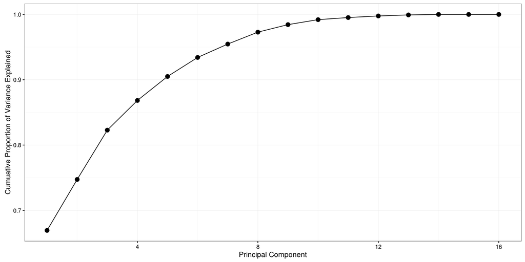

```r
#funçao disponibilizada pelo professor
# Porcentagem da variância explicada:
plot_pve <- function(prout){
  pr.var <- pr.out$sdev^2
  pve <- pr.var / sum(pr.var)
  df = data.frame(x = 1:NROW(pve), y = cumsum(pve))
  ggplot(df, aes(x = x, y = y)) +
    geom_point(size = 3) +
    geom_line() +
    labs(x='Principal Component', y = 'Cumuative Proportion of Variance Explained')
}

plot_pve(pr.out)
```

Como podemos perceber, quando reduzimos para duas dimensões, conseguimos explicar cerca de 75% da variância do dado original.

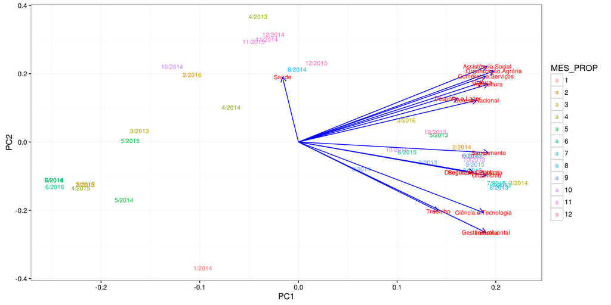

```r
#autoplot do pca
autoplot(pr.out, data = emendas_ano_log, colour = 'MES_PROP',
         loadings = TRUE, loadings.colour = 'blue',
         loadings.label = TRUE, loadings.label.size = 3,
         label= TRUE, shape=FALSE, label.size=3)
```

Aplicando os vetores de direcionamento com sua respectiva variável, funções imputadas (tipo de emenda), os vetores estão relacionados se as linhas estiverem perto ou até mesmo sobrepostas.

Primeiramente, podemos observar a existência quatro grupos principais de emendas:

- Primeiro grupo: Saúde
- Segundo grupo: Assistência Social, Organização Agrária, Comércio e Serviços, Cultura, Agricultura, Desporto e Lazer, Defesa Nacional
- Terceiro grupo: Saneamento, Segurança Pública, Direito e Cidadania, Urbanismo
- Quarto grupo: Ciência e Tecnologia, Trabalho, Gestão Ambiental, Indústria

Como tivemos os dados normalizados, utilizaremos ‘menor’ ou ‘maior’ como diferença entre os gastos e não o valor absoluto dos gastos.

Com isso, verificamos também que os meses iniciais, geralmente, possuem menor gastos, principalmente no Segundo Grupo de emendas. Também observamos que os meses finais de 2014 e 2015 tiveram um gasto maior em saúde.

Podemos notar uma pequena concentração de meses, (começando de junho) do final de 2013 e início de 2014, no Terceiro Grupo.

# t-SNE

Agora vamos reduzir as dimensões utilizando outra técnica chamada t-SNE:

```r
require(Rtsne)
tsne.dim = Rtsne(select(emendas_ano_cast, -MES_PROP, -ANO_PROP),
                 perplexity = 5,
                 verbose = TRUE,
                 check_duplicates = FALSE)
```

[output not shown]

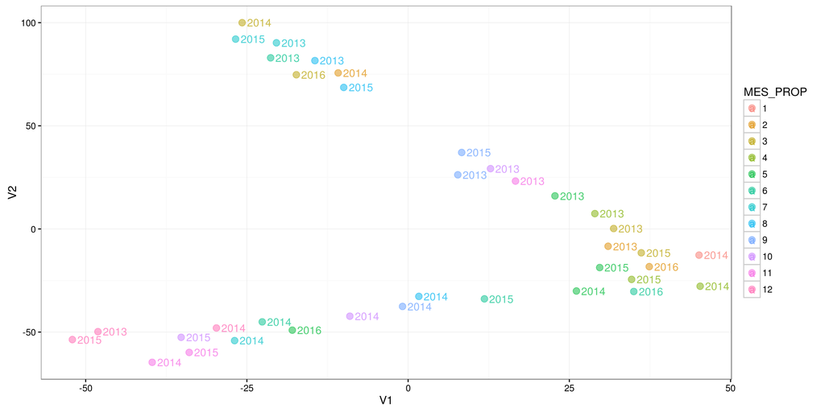

```r
df = as.data.frame(tsne.dim$Y)
df$MES_PROP = as.factor(emendas_ano_cast$MES_PROP)
df$ANO_PROP = as.factor(emendas_ano_cast$ANO_PROP)

ggplot(df, aes(x = V1, y = V2, label = ANO_PROP, color=MES_PROP)) +
  geom_point(alpha = 0.5, size = 3) +
  geom_text(alpha = .7, size = 4, hjust = -.2)
```

Gerando o gráfico podemos notar que os grupos são muito parecidos.